# Asset Pricing Architectures — CAPM, APT, and Risk-Adjusted Performance

**Market chosen:** USA (NYSE example)  
**Frequency:** Monthly (resampled from daily)  
**Window:** 5 years (60 monthly observations of returns)

This notebook is designed to be **production-ready**: it downloads data, cleans/aligned it, runs regressions, generates diagnostics tables, constructs the required portfolio, computes performance ratios, and produces the CML/SML charts.

## Data specification (what the notebook uses)

- **4 equities** (different sectors): adjusted close prices (monthly)
- **Market portfolio proxy (Rm):** NYSE Composite (default: `^NYA`) adjusted close prices (monthly)
- **Risk-free rate (Rf):** 3-month / 91-day Treasury Bill yield (FRED `TB3MS`, monthly, % annualized)
- **APT macro factors (2):** CPI level (FRED `CPIAUCSL`) and Fed Funds rate (FRED `FEDFUNDS`)

You may replace tickers/series IDs in the configuration cell below if your group decides to use a different market index or macro factor choices.

```
Repo root: D:\NSE-Asset
Outputs: D:\NSE-Asset\outputs
```

```
Assets: ['AAPL', 'JPM', 'XOM', 'PG']
Market: ^NYA
Window (download): 2020-05-19 to 2026-05-19
USE_CACHE: True FORCE_REFRESH: False
```

```
Saved: D:\NSE-Asset\data\raw\yahoo_adj_close_daily__AAPL__JPM__XOM__PG___NYA.csv
```

| Ticker Date | AAPL | JPM | XOM | PG |
| --- | --- | --- | --- | --- |
| 2026-05-12 | 294.799988 | 304.880005 | 149.614502 | 143.910004 |
| 2026-05-13 | 298.869995 | 300.250000 | 150.548172 | 142.240005 |
| 2026-05-14 | 298.209991 | 299.910004 | 151.750000 | 142.710007 |
| 2026-05-15 | 300.230011 | 297.809998 | 157.919998 | 141.570007 |
| 2026-05-18 | 297.839996 | 300.730011 | 160.490005 | 142.389999 |

| Ticker Date | MKT |
| --- | --- |
| 2026-05-12 | 23015.339844 |
| 2026-05-13 | 22973.550781 |
| 2026-05-14 | 23101.849609 |
| 2026-05-15 | 22799.429688 |
| 2026-05-18 | 22900.570312 |

```
Saved: D:\NSE-Asset\data\raw\fred__TB3MS.csv
Saved: D:\NSE-Asset\data\raw\fred__CPIAUCSL.csv
Saved: D:\NSE-Asset\data\raw\fred__FEDFUNDS.csv
Monthly observations: 60
Average annualized risk-free rate over window (mean TB3MS): 3.47%
```

|  | AAPL | JPM | XOM | PG | MKT | RF | RF_simple | RF_annual | Inflation_MoM_% | FedFunds_Δ_pp |
| --- | --- | --- | --- | --- | --- | --- | --- | --- | --- | --- |
| 2021-05-31 | -0.051817 | 0.065611 | 0.034012 | 0.010661 | 0.020524 | 0.000017 | 0.000017 | 0.0002 | 0.663506 | -0.01 |
| 2021-06-30 | 0.094500 | -0.054426 | 0.077602 | 0.000593 | -0.000019 | 0.000033 | 0.000033 | 0.0004 | 0.846179 | 0.02 |
| 2021-07-31 | 0.062958 | -0.018725 | -0.091402 | 0.058959 | 0.002831 | 0.000042 | 0.000042 | 0.0005 | 0.461475 | 0.02 |
| 2021-08-31 | 0.041611 | 0.052430 | -0.039412 | 0.001124 | 0.012222 | 0.000042 | 0.000042 | 0.0005 | 0.284293 | -0.01 |
| 2021-09-30 | -0.070462 | 0.023113 | 0.075914 | -0.018357 | -0.040157 | 0.000033 | 0.000033 | 0.0004 | 0.452552 | -0.01 |

# QUESTION ONE — Empirical CAPM Implementation & Regression Diagnostics

We run OLS regressions for each asset using the CAPM excess return structure:

$$ (R_{j,t} - R_{f,t}) = \alpha_j + \beta_j (R_{m,t} - R_{f,t}) + \epsilon_{j,t}. $$

Where returns are **monthly log returns** and $R_{f,t}$ is the monthly log return implied by the 3‑month (91‑day) T‑bill yield (`TB3MS`).

| Asset | Sector | Alpha | Beta | R2 | SE_Alpha | SE_Beta | t_Alpha | t_Beta | p_Alpha | p_Beta | Beta Class | Alpha Significant (5%) |
| --- | --- | --- | --- | --- | --- | --- | --- | --- | --- | --- | --- | --- |
| AAPL | Technology | 0.007011 | 0.864661 | 0.265278 | 0.007754 | 0.188948 | 0.904148 | 4.576181 | 0.369657 | 2.546121e-05 | Defensive (β<1) | False |
| JPM | Financials | 0.007303 | 1.235879 | 0.579848 | 0.005669 | 0.138137 | 1.288310 | 8.946795 | 0.202754 | 1.623288e-12 | Aggressive (β>1) | False |
| PG | Consumer Staples | -0.000986 | 0.614907 | 0.227269 | 0.006110 | 0.148881 | -0.161436 | 4.130187 | 0.872311 | 1.177607e-04 | Defensive (β<1) | False |
| XOM | Energy | 0.014931 | 0.633852 | 0.121774 | 0.009172 | 0.223512 | 1.627817 | 2.835880 | 0.108985 | 6.282534e-03 | Defensive (β<1) | False |

## Q1.4 — Portfolio beta (analytical vs direct regression)

We form an actively managed portfolio with weights $w = (0.30, 0.25, 0.20, 0.25)$.

**Analytical (weighted-average) beta** $$\beta_p = \sum_{i=1}^4 w_i\,\beta_i.$$

**Why the direct regression matches the weighted beta (sketch):** If portfolio excess return is the weighted sum of constituent excess returns, $$(R_{p,t}-R_{f,t}) = \sum_i w_i (R_{i,t}-R_{f,t}),$$ then $$\beta_p = \frac{\mathrm{Cov}(R_p-R_f,\,R_m-R_f)}{\mathrm{Var}(R_m-R_f)} = \sum_i w_i\beta_i.$$

|  | Beta_Analytical | Beta_DirectRegression | Abs_Diff | Alpha_Direct | R2_Direct |
| --- | --- | --- | --- | --- | --- |
| Portfolio | 0.848865 | 0.848865 | 1.110223e-16 | 0.006669 | 0.739377 |

```
1837
```

## Q1.5 — Interpretation (SML, alpha, and cost of equity)

Under CAPM equilibrium, security alpha is expected to decay toward zero because persistent mispricing invites arbitrage.

- If an asset plots **above** the Security Market Line (SML), it has **positive alpha** (higher realized/expected return than implied by its beta). A financial engineer may overweight/hold it, or design a hedged trade to isolate the mispricing while controlling market exposure.
- If an asset plots **below** the SML, it has **negative alpha** (underperforms given beta). One may underweight it, short it, or pair it against a similar exposure to capture the expected convergence toward fair pricing.
- **Systematic risk (β)** affects the **cost of equity** via the CAPM required return: $$E[R_j] = R_f + \beta_j(E[R_m]-R_f).$$ Higher beta raises the required return, increasing discount rates used in valuation and increasing the hurdle rate for equity financing.

# QUESTION TWO — Multi-Factor Extraction & Arbitrage Pricing Modelling (APT)

We model excess returns using two macro factors (monthly):

- $F_1$: **Inflation** (CPI month‑over‑month % change)
- $F_2$: **Interest-rate shock** (Fed Funds rate monthly change in percentage points)

A practical regression form is: $$ (R_{j,t}-R_{f,t}) = \alpha_j + \beta_{j,F1} F_{1,t} + \beta_{j,F2} F_{2,t} + e_{j,t}. $$

To improve comparability, we standardize factors to z‑scores before regression (mean 0, std 1).

|  | count | mean | std | min | 25% | 50% | 75% | max |
| --- | --- | --- | --- | --- | --- | --- | --- | --- |
| F1_Inflation_z | 60.0 | 1.609823e-16 | 1.0 | -1.428898 | -0.691352 | -0.272589 | 0.342240 | 3.088963 |
| F2_RateShock_z | 60.0 | 3.885781e-17 | 1.0 | -1.807529 | -0.299160 | -0.299160 | 0.153351 | 3.220367 |

| Asset | Sector | Alpha | Beta_F1_Inflation | Beta_F2_RateShock | R2 | F_stat | p_F | p_Alpha | p_F1 | p_F2 |
| --- | --- | --- | --- | --- | --- | --- | --- | --- | --- | --- |
| AAPL | Technology | 0.009688 | -0.004379 | -0.004609 | 0.009493 | 0.273129 | 0.761985 | 0.289197 | 0.636150 | 0.618564 |
| JPM | Financials | 0.011130 | -0.009894 | 0.002067 | 0.021615 | 0.629625 | 0.536456 | 0.206018 | 0.268101 | 0.816068 |
| PG | Consumer Staples | 0.000918 | -0.008096 | 0.001852 | 0.022998 | 0.670870 | 0.515254 | 0.894796 | 0.254007 | 0.792984 |
| XOM | Energy | 0.016894 | 0.011687 | 0.006625 | 0.035631 | 1.053015 | 0.355572 | 0.085954 | 0.239355 | 0.503023 |

| Asset | CAPM_R2 | APT_R2 | Δ_R2 (APT-CAPM) |
| --- | --- | --- | --- |
| AAPL | 0.265278 | 0.009493 | -0.255786 |
| JPM | 0.579848 | 0.021615 | -0.558233 |
| PG | 0.227269 | 0.022998 | -0.204271 |
| XOM | 0.121774 | 0.035631 | -0.086142 |

## Q2.3 — Factor interpretation (example logic)

- A **negative inflation beta** ($\beta_{\text{Inf}}<0$) means the asset’s excess returns tend to **fall when inflation rises** (in standardized terms). A portfolio manager may treat it as **poor inflation protection**, while an asset with $\beta_{\text{Inf}}>0$ behaves more like an inflation‑sensitive exposure.
- A **positive rate‑shock beta** suggests the asset benefits (or is less harmed) when policy rates rise; a negative beta suggests rate hikes are typically bad for the asset.
- The $R^2$ comparison above shows whether the 2‑factor macro model explains more variance than CAPM’s single market factor.

```
Highest APT alpha asset: XOM alpha= 0.01689373514740741
Lowest  APT alpha asset: PG alpha= 0.0009178737784645442

Arbitrage weights (gross=1, self-financing):
```

|  | AAPL | JPM | XOM | PG |
| --- | --- | --- | --- | --- |
| weight | 0.037913 | 0.430117 | 0.03197 | -0.5 |

```
Sum weights: 0.0
Factor exposures (target 0):
```

|  | Beta_F1_Inflation | Beta_F2_RateShock |
| --- | --- | --- |
| exposure | -3.794708e-19 | 2.168404e-19 |

```
Portfolio APT alpha (monthly): 0.005235795648290426
Portfolio APT alpha (annualized approx): 0.06282954777948511
                            OLS Regression Results
==============================================================================
Dep. Variable:             ARB_EXCESS   R-squared:                       0.000
Model:                            OLS   Adj. R-squared:                 -0.035
Method:                 Least Squares   F-statistic:                     0.000
Date:                Tue, 19 May 2026   Prob (F-statistic):               1.00
Time:                        18:55:07   Log-Likelihood:                 113.31
No. Observations:                  60   AIC:                            -220.6
Df Residuals:                      57   BIC:                            -214.3
Df Model:                           2
Covariance Type:            nonrobust
==================================================================================
                     coef    std err          t      P>|t|      [0.025      0.975]
----------------------------------------------------------------------------------
const              0.0052      0.005      1.080      0.285      -0.004       0.015
F1_Inflation_z  4.337e-19      0.005    8.8e-17      1.000      -0.010       0.010
F2_RateShock_z  4.337e-19      0.005    8.8e-17      1.000      -0.010       0.010
==============================================================================
Omnibus:                        0.598   Durbin-Watson:                   2.458
Prob(Omnibus):                  0.742   Jarque-Bera (JB):                0.605
Skew:                          -0.224   Prob(JB):                        0.739
Kurtosis:                       2.799   Cond. No.                         1.14
==============================================================================

Notes:
[1] Standard Errors assume that the covariance matrix of the errors is correctly specified.
```

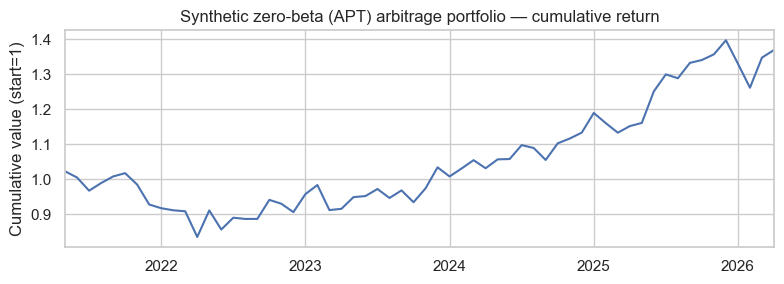

## Q2.5 — Practical APT limitations (real-world quant desks)

- **Factor selection & stability:** macro factors can change relevance across regimes; relationships estimated in one period may break in another.
- **Measurement & timing:** many macro series are revised, released with lags, and can be noisy at monthly frequency.
- **Estimation error:** betas and alphas are sample estimates; small universes (few assets) make factor‑premium inference fragile.
- **Regime shifts:** crises and policy changes cause time‑varying betas and non‑linear behavior (APT’s linear assumption can fail).
- **Implementation costs:** trading to maintain factor‑neutral portfolios incurs transaction costs and shorting/financing constraints.

# QUESTION THREE — Portfolio Diagnostic Optimization & Performance Metrics

We compute annualized return/volatility, then evaluate assets and the constructed portfolio using:

- Sharpe Ratio (total risk)
- Treynor Ratio (systematic risk)
- Jensen’s Alpha (CAPM abnormal return)

We also plot:

- **CML:** Expected return vs total volatility
- **SML:** Expected return vs beta

| Name | Type | Sector | R_ann | Sigma_ann | Beta | Sharpe | Treynor | Jensen_Alpha | Rank_Sharpe | Rank_Treynor | Rank_Jensen_Alpha |
| --- | --- | --- | --- | --- | --- | --- | --- | --- | --- | --- | --- |
| AAPL | Asset | Technology | 0.179871 | 0.243586 | 0.864661 | 0.595954 | 0.167888 | 0.104710 | 4.0 | 2.0 | 2.0 |
| JPM | Asset | Financials | 0.195826 | 0.236792 | 1.235879 | 0.680432 | 0.130370 | 0.103296 | 3.0 | 4.0 | 3.0 |
| MKT | Market | ^NYA | 0.081493 | 0.143706 | 1.000000 | 0.325585 | 0.046788 | 0.000000 | 5.0 | 5.0 | 5.0 |
| PG | Asset | Consumer Staples | 0.061781 | 0.184723 | 0.614907 | 0.146576 | 0.044032 | -0.001695 | 6.0 | 6.0 | 6.0 |
| PORT | Portfolio | (blend) | 0.172948 | 0.143525 | 0.848865 | 0.963198 | 0.162856 | 0.098526 | 1.0 | 3.0 | 4.0 |
| RF | RiskFree | TB3MS | 0.034705 | 0.000000 | 0.000000 | NaN | NaN | 0.000000 | NaN | NaN | 5.0 |
| XOM | Asset | Energy | 0.272923 | 0.268562 | 0.633852 | 0.887012 | 0.375826 | 0.208561 | 2.0 | 1.0 | 1.0 |

```
Saved: D:\NSE-Asset\outputs\summary_tables.xlsx
```

## Q3.3 — Why Treynor vs Sharpe rankings can differ

- **Sharpe** uses **total risk** ($\sigma$). It penalizes both systematic risk (market-related) and idiosyncratic risk (asset-specific).
- **Treynor** uses **systematic risk only** ($\beta$). An asset can look strong on Treynor if it has high return per unit of market risk, even if it still has large idiosyncratic volatility that Sharpe penalizes.
- Therefore, concentrated stocks (high idiosyncratic variance) often rank worse on Sharpe than on Treynor, while well-diversified portfolios typically improve on Sharpe.

```
Saved: D:\NSE-Asset\outputs\cml_sml_dual.png
```

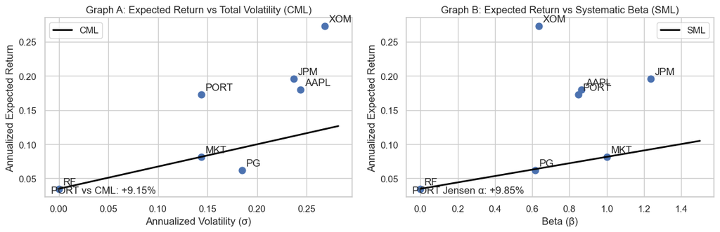

## Q3.5 — Using Jensen’s alpha in practical rebalancing

A quant analyst can treat **positive Jensen’s alpha** ($\alpha>0$) as evidence that an asset has delivered returns above what CAPM would require for its beta exposure. In an automated strategy, one common workflow is:

- Estimate rolling betas and rolling alphas (e.g., 24–36 months).
- Tilt weights upward for assets with persistently positive, statistically stable alphas, while controlling risk via beta/volatility constraints.
- Rebalance periodically (monthly/quarterly) and include transaction-cost and turnover limits so the alpha signal is not over-traded.